# Linear Regression Models

# **Analyze Motor Car Data Trends**

**Data Source:** from MASS library in R.

## **Data Dictionary**

This dataset contains the following columns:

| **Variable** | **Data Type** | **Description** | **Constraints/Rules** |
| --- | --- | --- | --- |
| `mpg` | Numeric | Miles per gallon | Positive values only (mpg > 0) |
| `cyl` | Integer | Number of cylinders | Categorical: {4, 6, 8} |
| `disp` | Numeric | Displacement (cubic inches) | Positive values only (disp > 0) |
| `hp` | Integer | Gross horsepower | Positive values only (hp > 0) |
| `drat` | Numeric | Rear axle ratio | Positive values only (drat > 0) |
| `wt` | Numeric | Weight (1000 lbs) | Positive values only (wt > 0) |
| `qsec` | Numeric | 1/4 mile time (seconds) | Positive values only (qsec > 0) |
| `vs` | Integer | Engine type: 0 = V-shaped, 1 = straight | Binary: {0, 1} |
| `am` | Integer | Transmission: 0 = automatic, 1 = manual | Binary: {0, 1} |
| `gear` | Integer | Number of forward gears | Categorical: {3, 4, 5} |
| `carb` | Integer | Number of carburetors | Positive integer values only |

## **Dataset Loading**

```r
# Load the Boston dataset
mtcars <- read_excel("data/mtcars.xlsx", sheet = "mtcars")
```

Check the dimension of the data frame

```r
dim(mtcars)
```

```
## [1] 41 12
```

Display data frame column names

```r
colnames(mtcars)
```

```
##  [1] "name" "mpg"  "cyl"  "disp" "hp"   "drat" "wt"   "qsec" "vs"   "am"
## [11] "gear" "carb"
```

Display data frame structures

```r
str(mtcars)
```

```
## tibble [41 × 12] (S3: tbl_df/tbl/data.frame)
##  $ name: chr [1:41] "Mazda RX4" "Mazda RX4 Wag" "Datsun 710" "Hornet 4 Drive" ...
##  $ mpg : num [1:41] 21 21 22.8 21.4 18.7 18.1 14.3 24.4 22.8 19.2 ...
##  $ cyl : num [1:41] 6 6 4 6 8 6 8 4 4 6 ...
##  $ disp: num [1:41] 160 160 108 258 360 ...
##  $ hp  : num [1:41] 110 110 93 110 175 105 245 62 95 123 ...
##  $ drat: num [1:41] 3.9 3.9 3.85 3.08 3.15 2.76 3.21 3.69 3.92 3.92 ...
##  $ wt  : num [1:41] 2.62 2.88 2.32 3.21 3.44 ...
##  $ qsec: num [1:41] 16.5 17 18.6 19.4 17 ...
##  $ vs  : num [1:41] 0 0 1 1 0 1 0 1 1 1 ...
##  $ am  : num [1:41] 1 1 1 0 0 0 0 0 0 0 ...
##  $ gear: num [1:41] 4 4 4 3 3 3 3 4 4 4 ...
##  $ carb: num [1:41] 4 4 1 1 2 1 4 2 2 4 ...
```

Display data frame statistical summary

```r
summary(mtcars)
```

```
##      name                mpg             cyl             disp
##  Length:41          Min.   :10.40   Min.   :4.000   Min.   : 71.1
##  Class :character   1st Qu.:15.80   1st Qu.:4.000   1st Qu.:121.0
##  Mode  :character   Median :19.70   Median :6.000   Median :167.6
##                     Mean   :20.15   Mean   :6.098   Mean   :226.4
##                     3rd Qu.:22.80   3rd Qu.:8.000   3rd Qu.:318.0
##                     Max.   :33.90   Max.   :8.000   Max.   :472.0
##        hp             drat             wt             qsec
##  Min.   : 52.0   Min.   :2.760   Min.   :1.513   Min.   :14.50
##  1st Qu.: 97.0   1st Qu.:3.080   1st Qu.:2.620   1st Qu.:16.90
##  Median :110.0   Median :3.690   Median :3.215   Median :17.82
##  Mean   :141.8   Mean   :3.579   Mean   :3.181   Mean   :17.91
##  3rd Qu.:180.0   3rd Qu.:3.920   3rd Qu.:3.570   3rd Qu.:18.90
##  Max.   :335.0   Max.   :4.930   Max.   :5.424   Max.   :22.90
##        vs               am              gear            carb
##  Min.   :0.0000   Min.   :0.0000   Min.   :3.000   Min.   :1.000
##  1st Qu.:0.0000   1st Qu.:0.0000   1st Qu.:3.000   1st Qu.:2.000
##  Median :0.0000   Median :0.0000   Median :4.000   Median :2.000
##  Mean   :0.4634   Mean   :0.4146   Mean   :3.659   Mean   :2.707
##  3rd Qu.:1.0000   3rd Qu.:1.0000   3rd Qu.:4.000   3rd Qu.:4.000
##  Max.   :1.0000   Max.   :1.0000   Max.   :5.000   Max.   :8.000
```

## **Question 1**

**Use the lm() function to perform a simple linear regression with the response mpg and the predictor hp.**

Visualize the data pairwise

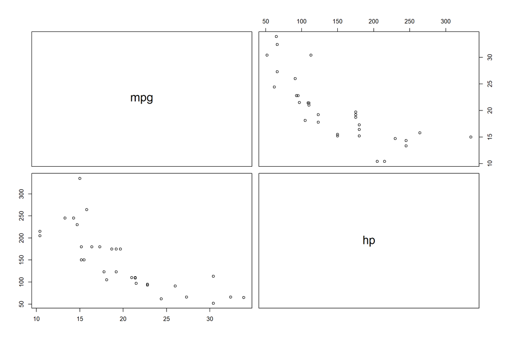

```r
pairs(mtcars[,c("mpg","hp")])
```

Build the simple linear model

```r
simple_model = lm(mpg ~ hp, data = mtcars)
```

Print out the model results

```r
summary(simple_model)
```

```
##
## Call:
## lm(formula = mpg ~ hp, data = mtcars)
##
## Residuals:
##     Min      1Q  Median      3Q     Max
## -5.6657 -1.2794 -0.7977  0.8162  8.7977
##
## Coefficients:
##              Estimate Std. Error t value Pr(>|t|)
## (Intercept) 29.297928   1.314115  22.295  < 2e-16 ***
## hp          -0.064548   0.008429  -7.658 2.72e-09 ***
## ---
## Signif. codes:  0 '***' 0.001 '**' 0.01 '*' 0.05 '.' 0.1 ' ' 1
##
## Residual standard error: 3.5 on 39 degrees of freedom
## Multiple R-squared:  0.6006, Adjusted R-squared:  0.5904
## F-statistic: 58.65 on 1 and 39 DF,  p-value: 2.723e-09
```

## **Question 2**

**Is there a relationship between the target mpg and predator hp?**

**Yes**, the t-test for hp results in a p-value of 2.72e-09, which is significantly low, indicating a strong relationship. Since this is a simple linear regression, the F-test yields the same conclusion:

- t-value = -7.658
- Squaring the t-value: (-7.658)^2 = 58.65, which equals the F-value

Thus, the p-values from both the t-test and F-test are identical in this case.

## **Question 3**

**How strong is the relationship between the response and predictor?**

The p-value from the t-test is far below the **0.05** threshold, indicating a **strong relationship** between the predictor and the response variable. Additionally, the R^2 value suggests that this variable alone explains **60%** of the variation in the model. The F-test can also serve as a useful indicator.

## **Question 4**

**Is the relationship between mpg and hp positive or negative?**

**Negative**, as hp goes up, mpg goes down.

## **Question 5**

**What is the predicted mpg associated with a horsepower (hp) of 100? What’s the 95% confidence interval for the predicted mpg?**

Predict mpg for hp = 100 with 95% confidence interval

```r
predicted_mpg <- predict(simple_model, data.frame(hp = 100),
                         interval = "confidence", level = 0.95)
```

Print the predicted mpg

```r
predicted_mpg
```

```
##        fit     lwr      upr
## 1 22.84317 21.5279 24.15844
```

## **Question 6**

**Plot the response and the predictor and add the regression line using abline().**

Plot the response and predictor with the regression line

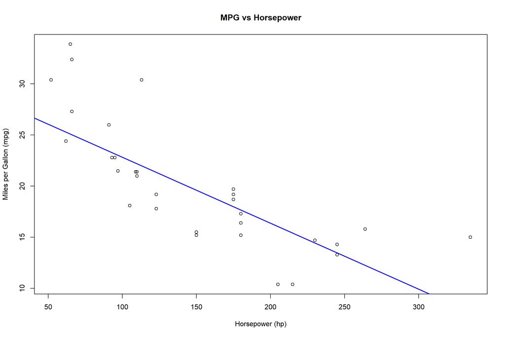

```r
plot(mtcars$hp, mtcars$mpg, main = "MPG vs Horsepower",
     xlab = "Horsepower (hp)", ylab = "Miles per Gallon (mpg)")
abline(simple_model, lwd = 2, col = "blue")
```

## **Question 7**

**Perform a multiple linear regression with mpg as the response and the predictors cyl, disp, hp, wt, vs, and gear. Print out the results using summary() function.**

Perform multiple linear regression

```r
multiple_model <- lm(mpg ~ cyl + disp + hp + wt + vs + gear, data = mtcars)
```

Print the summary of the model

```r
summary(multiple_model)
```

```
##
## Call:
## lm(formula = mpg ~ cyl + disp + hp + wt + vs + gear, data = mtcars)
##
## Residuals:
##     Min      1Q  Median      3Q     Max
## -2.5877 -1.8021 -0.3745  0.8538  6.3448
##
## Coefficients:
##             Estimate Std. Error t value Pr(>|t|)
## (Intercept) 33.29705    6.58333   5.058 1.45e-05 ***
## cyl         -0.74909    0.74433  -1.006  0.32133
## disp         0.01733    0.01086   1.596  0.11981
## hp          -0.03352    0.01381  -2.428  0.02061 *
## wt          -3.85230    0.88681  -4.344  0.00012 ***
## vs           0.70816    1.39192   0.509  0.61420
## gear         1.14054    0.95373   1.196  0.24002
## ---
## Signif. codes:  0 '***' 0.001 '**' 0.01 '*' 0.05 '.' 0.1 ' ' 1
##
## Residual standard error: 2.348 on 34 degrees of freedom
## Multiple R-squared:  0.8433, Adjusted R-squared:  0.8157
## F-statistic:  30.5 on 6 and 34 DF,  p-value: 2.568e-12
```

## **Question 8**

**Is there a relationship between the predictors and the response?**

**Yes**, some predictors show a significant relationship with the response variable, as evidenced by the F-statistic of 30.5 and a p-value of 2.568e-12.

## **Question 9**

**Which predictors appears to have a statistically significant relationship to the response?**

The variables **wt** (weight) and **hp** (gross horsepower) have p-values of **0.00012** and **0.02**, respectively, based on their t-tests.

## **Question 10**

**Use * symbols to fit linear regression models with interaction effects between hp and wt. Does this interaction appear to be statistically significant?**

Fit a model with interaction effects between hp and wt

```r
interaction_model <- lm(mpg ~ hp * wt, data = mtcars)
```

Print the summary of the interaction model

```r
summary(interaction_model)
```

```
##
## Call:
## lm(formula = mpg ~ hp * wt, data = mtcars)
##
## Residuals:
##     Min      1Q  Median      3Q     Max
## -2.9170 -1.6420 -0.7411  1.4507  4.7557
##
## Coefficients:
##             Estimate Std. Error t value Pr(>|t|)
## (Intercept) 48.66145    3.29797  14.755  < 2e-16 ***
## hp          -0.11778    0.02277  -5.174 8.24e-06 ***
## wt          -7.76370    1.12887  -6.877 4.13e-08 ***
## hp:wt        0.02642    0.00673   3.926 0.000362 ***
## ---
## Signif. codes:  0 '***' 0.001 '**' 0.01 '*' 0.05 '.' 0.1 ' ' 1
##
## Residual standard error: 2.048 on 37 degrees of freedom
## Multiple R-squared:  0.8703, Adjusted R-squared:  0.8598
## F-statistic: 82.77 on 3 and 37 DF,  p-value: < 2.2e-16
```

**Yes**, the interaction has a p-value of 0.000362 < alpha = 0.05